# SNA PRACTICALS

Submitted by- Priyanshi Jain 16120

```python
import networkx as nx
import matplotlib.pyplot as plt
import numpy as np
from networkx.algorithms import community
from sklearn.metrics.cluster import normalized_mutual_info_score
from tqdm import trange
import random
```

Problem 1-A Plot a weighted directed network such that the node size and edge width is proportional to the degree and edge weight respectively. Modify the edge length with respect to edge weight and show the plot of the node size with respect to the in-degree and out-degree.

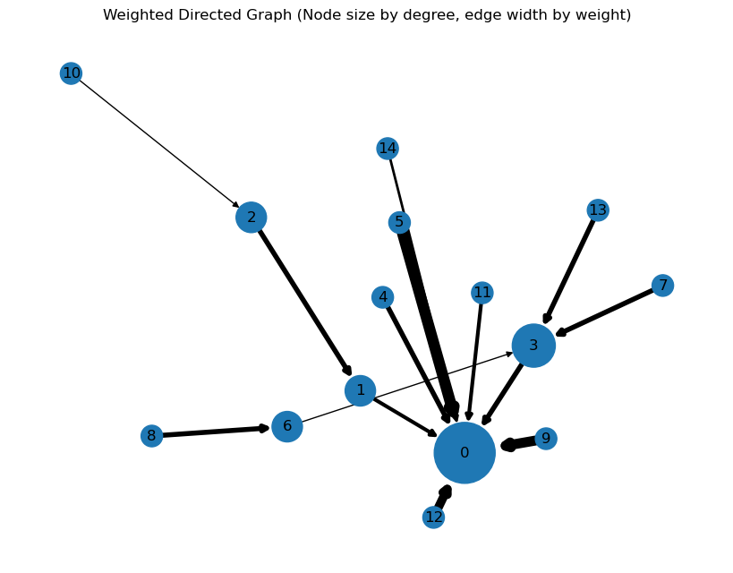

```python
G = nx.gn_graph(15, seed=42)
for u, v in G.edges():
    G[u][v]['weight'] = np.random.randint(1, 10)

node_sizes = [G.degree(n) * 300 for n in G.nodes()]

edge_widths = [G[u][v]['weight'] for u, v in G.edges()]

pos = nx.spring_layout(G, weight='weight')

plt.figure(figsize=(8,6))
nx.draw(G, pos, with_labels=True, node_size=node_sizes,
        width=edge_widths, edge_color='black', arrows=True)
plt.title("Weighted Directed Graph (Node size by degree, edge width by weight)")
plt.show()
```

Problem 1-B Plot a weighted undirected network such that node size, edge width and edge length is proportional to degree and edge weight

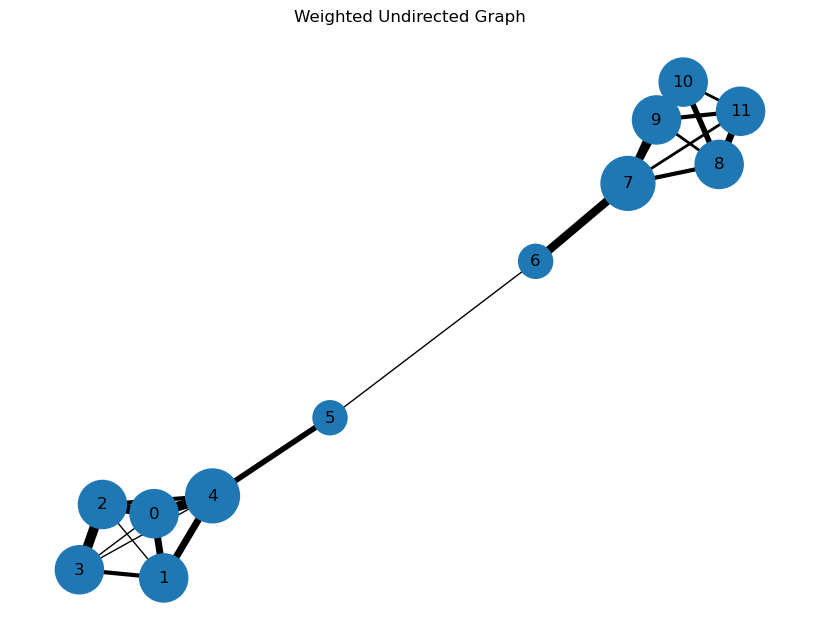

```python
G = nx.barbell_graph(5, 2)
for u, v in G.edges():
    G[u][v]['weight'] = np.random.randint(1, 10)

node_sizes = [G.degree(n) * 300 for n in G.nodes()]
edge_widths = [G[u][v]['weight'] for u, v in G.edges()]

pos = nx.spring_layout(G, weight='weight')

plt.figure(figsize=(8,6))
nx.draw(G, pos, with_labels=True, node_size=node_sizes,
        width=edge_widths, edge_color='black')
plt.title("Weighted Undirected Graph")
plt.show()
```

Problem 2-A Compute and plot the degree distribution of a real world network. also compute local and global properties of the n/w. Local Properties: Local Clustering Coefficient Global Properties: Global clustering coefficient, degree centrality, closeness centrality, betweenness centrality

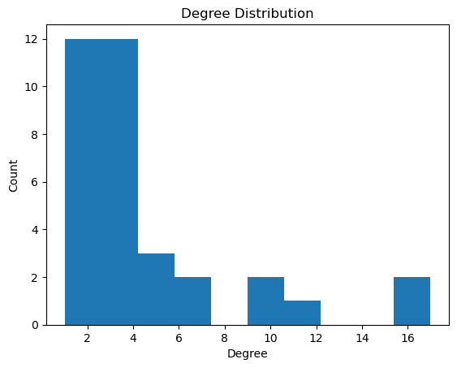

```
Local Clustering Coefficient: 0.5706384782076823
Global Clustering Coefficient: 0.2556818181818182
Degree Centrality: {16: 4.3125, 9: 5.777777777777778, 10: 6.6, 6: 8.333333333333334, 3: 8.222222222222221, 4: 8.541666666666666, 5: 10.466666666666667, 2: 12.409090909090908, 1: 16.0, 12: 5.083333333333333, 17: 3.823529411764706}
Closeness Centrality: {0: 0.5689655172413793, 1: 0.4852941176470588, 2: 0.559322033898305, 3: 0.4647887323943662, 4: 0.3793103448275862, 5: 0.38372093023255816, 6: 0.38372093023255816, 7: 0.44, 8: 0.515625, 9: 0.4342105263157895, 10: 0.3793103448275862, 11: 0.36666666666666664, 12: 0.370786516853932…
Betweenness Centrality: {0: 0.43763528138528146, 1: 0.053936688311688304, 2: 0.14365680615680618, 3: 0.011909271284271283, 4: 0.0006313131313131313, 5: 0.02998737373737374, 6: 0.029987373737373736, 7: 0.0, 8: 0.05592682780182781, 9: 0.0008477633477633478, 10: 0.0006313131313131313, 11: 0.0, 12: 0.0,…
```

```python
G = nx.karate_club_graph()

degrees = [G.degree(n) for n in G.nodes()]
plt.hist(degrees, bins=10)
plt.title("Degree Distribution")
plt.xlabel("Degree")
plt.ylabel("Count")
plt.show()

print("Local Clustering Coefficient:", nx.average_clustering(G))
print("Global Clustering Coefficient:", nx.transitivity(G))
print("Degree Centrality:", nx.average_degree_connectivity(G))
print("Closeness Centrality:", nx.closeness_centrality(G))
print("Betweenness Centrality:", nx.betweenness_centrality(G))
```

Problem 2-B Implement the Page Rank Algorithm and calculate the number of iterations required to determine the convergence point and Validate the result with the pre-defined page rank function.

```python
def page_rank(G, d=0.85, max_iter=100, tol=1e-6):
    N = len(G)
    P = np.ones(N) / N
    A = nx.to_numpy_array(G)
    outdeg = A.sum(axis=1)

    for i in range(max_iter):
        P_new = np.zeros(N)
        for n in range(N):
            P_new[n] = (1-d)/N + d * sum(P[j]/outdeg[j] for j in range(N) if A[j][n] > 0)
        if np.linalg.norm(P_new-P) < tol:
            print("Converged at iteration:", i)
            break
        P = P_new
    return P

G = nx.karate_club_graph()
pr = page_rank(G)
print("Custom PR:", pr)
print("NetworkX PR:", nx.pagerank(G))
```

```
Converged at iteration: 10
Custom PR: [0.01428115 0.0097069  0.00902374 0.00694    0.00572796 0.0064683
 0.00644251 0.00554556 0.00588522 0.00491761 0.00570218 0.00470082
 0.00502857 0.00581896 0.00493743 0.00493743 0.00522576 0.00498536
 0.00493743 0.00525876 0.00493743 0.00498536 0.00493743 0.00604352
 0.00541377 0.00559554 0.00507098 0.00581965 0.00519935 0.00590047
 0.00551625 0.00696024 0.01127688 0.0154372 ]
NetworkX PR: {0: 0.08850807396280012, 1: 0.057414840497110056, 2: 0.06276686454603017, 3: 0.03721208153631377, 4: 0.020503977347501652, 5: 0.03381044255357727, 6: 0.03152901134345504, 7: 0.026464618678806107, 8: 0.03338155566846444, 9: 0.009463219565799959, 10: 0.020689016083505596, 11: 0.0097856865…
```

Problem 1 On Real world network Use the BALI terrorist network for the following two tasks.

1. Plot an unweighted, undirected network such that the node size is proportional to the degree.
2. Plot a weighted directed network such that the node and edge width is proportional to the in-degree and edge weight respectively. Experiment with different layouts for visualization.

```
   Source    Target  Weight
0  Muklas    Amrozi       2
1  Muklas     Imron       2
2  Muklas   Samudra       1
3  Muklas  Dulmatin       1
4  Muklas     Idris       5
Index(['Source', 'Target', 'Weight'], dtype='object')
```

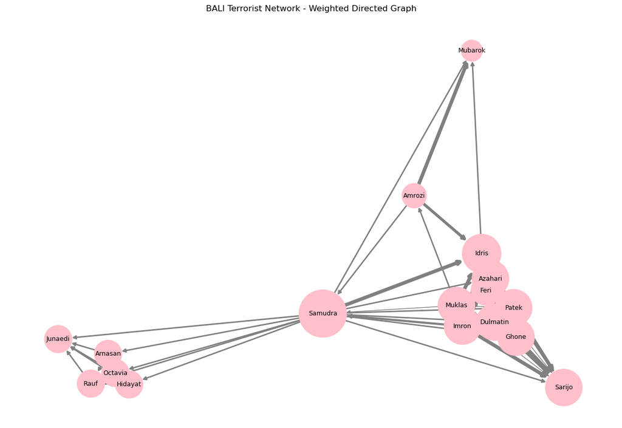

```
Nodes: 17
Edges: 63
```

```python
file_path = r"C:\Users\PRIYANSHI\Desktop\sna project\datasets\Bali.txt"
df = pd.read_csv(file_path, sep="\s+", header=None, names=["Source", "Target", "Weight"])

print(df.head())
print(df.columns)

G = nx.from_pandas_edgelist(df, "Source", "Target", edge_attr="Weight", create_using=nx.DiGraph())

node_sizes = [G.degree(n) * 300 for n in G.nodes()]
edge_widths = [G[u][v]['Weight'] for u,v in G.edges()]

pos = nx.spring_layout(G, k=0.3, iterations=50)

plt.figure(figsize=(12, 8))
nx.draw(G, pos,
        node_size=node_sizes,
        width=edge_widths,
        with_labels=True,
        edge_color="gray",
        node_color="pink",
        arrows=True,
        font_size=9)

plt.title("BALI Terrorist Network - Weighted Directed Graph")
plt.show()

print("Nodes:", G.number_of_nodes())
print("Edges:", G.number_of_edges())
```

Problem 3 Generate networks of 1000 nodes each using Random Network Model, Watts Strogatz (Small World) Network Model, Barabassi Albert (Preferential Attachment) Model and compare their characteristics.

```python
G1 = nx.erdos_renyi_graph(1000, 0.01)
G2 = nx.watts_strogatz_graph(1000, 10, 0.3)
G3 = nx.barabasi_albert_graph(1000, 5)

print(nx.average_clustering(G1), nx.average_clustering(G2), nx.average_clustering(G3))
print(nx.average_shortest_path_length(G1), nx.average_shortest_path_length(G2), nx.average_shortest_path_length(G3))
```

```
0.010666432827578346 0.23369030414030423 0.03887148887623758
3.2538738738738737 3.6107927927927927 2.9633673673673675
```

Problem 4 Compute different centrality measures to identify top-N nodes and compare their ranks with those obtained by PageRank method.

- Using Karate Club Network

```python
G = nx.karate_club_graph()

dc = nx.degree_centrality(G)
bc = nx.betweenness_centrality(G)
pr = nx.pagerank(G)

df = pd.DataFrame({
    "Node": list(dc.keys()),
    "DegreeCentrality": list(dc.values()),
    "BetweennessCentrality": list(bc.values()),
    "PageRank": list(pr.values())
})

print(df.sort_values("PageRank", ascending=False).head())
```

```
    Node  DegreeCentrality  BetweennessCentrality  PageRank
33    33          0.515152               0.304075  0.096980
0      0          0.484848               0.437635  0.088508
32    32          0.363636               0.145247  0.075926
2      2          0.303030               0.143657  0.062767
1      1          0.272727               0.053937  0.057415
```

Problem 5 Apply various community detection algorithms on a small real-world network (e.g. Karate club) and plot the communities revealed with different colors. Also, compare the results of these algorithms using any two evaluation measures studied. Show the comparative results using bar plots.

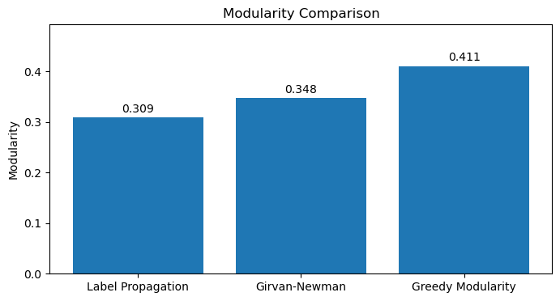

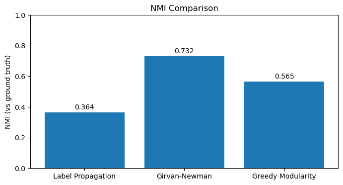

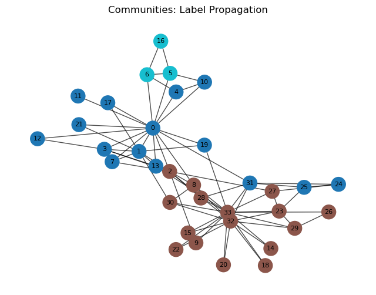

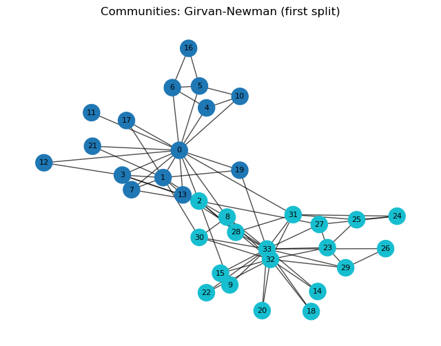

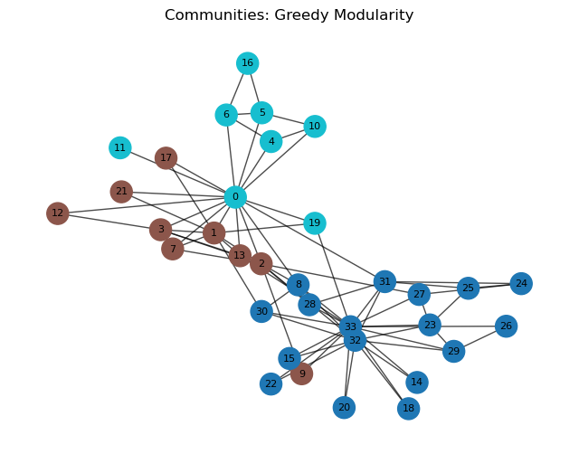

```python
np.random.seed(42)
G = nx.karate_club_graph()

ground_truth = [G.nodes[n]['club'] for n in G.nodes()]
gt_map = {name: i for i, name in enumerate(sorted(set(ground_truth)))}
gt_labels = np.array([gt_map[x] for x in ground_truth])

lp_comm = list(community.label_propagation_communities(G))
def partition_to_labels(partition):
    labels = np.zeros(len(G.nodes()), dtype=int)
    for cid, community_nodes in enumerate(partition):
        for node in community_nodes:
            labels[node] = cid
    return labels

lp_labels = partition_to_labels(lp_comm)

gn_gen = community.girvan_newman(G)
gn_comm = tuple(sorted(c) for c in next(gn_gen))
gn_labels = partition_to_labels(gn_comm)

gm_comm = community.greedy_modularity_communities(G)
gm_comm_sets = [set(c) for c in gm_comm]
gm_labels = partition_to_labels(gm_comm_sets)

mod_lp = community.modularity(G, [set(c) for c in lp_comm])
mod_gn = community.modularity(G, [set(c) for c in gn_comm])
mod_gm = community.modularity(G, gm_comm_sets)

nmi_lp = normalized_mutual_info_score(gt_labels, lp_labels)
nmi_gn = normalized_mutual_info_score(gt_labels, gn_labels)
nmi_gm = normalized_mutual_info_score(gt_labels, gm_labels)

algos = ["Label Propagation", "Girvan-Newman", "Greedy Modularity"]
mod_scores = [mod_lp, mod_gn, mod_gm]
nmi_scores = [nmi_lp, nmi_gn, nmi_gm]

plt.figure(figsize=(8,4))
plt.bar(algos, mod_scores)
plt.ylabel("Modularity")
plt.title("Modularity Comparison")
plt.ylim(0, max(mod_scores)*1.2)
for i,v in enumerate(mod_scores):
    plt.text(i, v+0.01, f"{v:.3f}", ha='center')
plt.show()

plt.figure(figsize=(8,4))
plt.bar(algos, nmi_scores)
plt.ylabel("NMI (vs ground truth)")
plt.title("NMI Comparison")
plt.ylim(0, 1)
for i,v in enumerate(nmi_scores):
    plt.text(i, v+0.02, f"{v:.3f}", ha='center')
plt.show()

def plot_partition(G, labels, title):
    plt.figure(figsize=(8,6))
    pos = nx.spring_layout(G, seed=42)
    unique_labels = np.unique(labels)
    cmap = plt.cm.get_cmap('tab10', len(unique_labels))
    node_colors = [cmap(label % 10) for label in labels]
    nx.draw_networkx_nodes(G, pos, node_color=node_colors, node_size=300)
    nx.draw_networkx_edges(G, pos, alpha=0.7)
    nx.draw_networkx_labels(G, pos, font_size=8)
    plt.title(title)
    plt.axis('off')
    plt.show()

plot_partition(G, lp_labels, "Communities: Label Propagation")
plot_partition(G, gn_labels, "Communities: Girvan-Newman (first split)")
plot_partition(G, gm_labels, "Communities: Greedy Modularity")
```

Problem 6 Simulate diffusion trends for different epidemic models and present results using appropriate visuals.

```
Simulating... (this may take a moment)
```

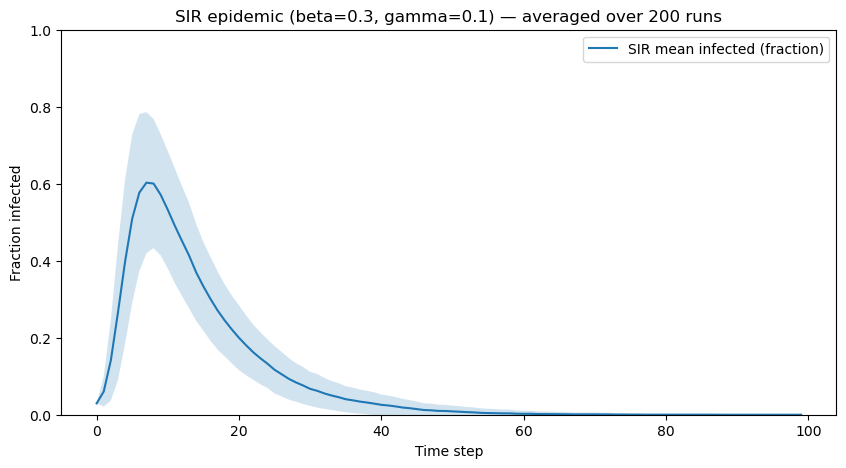

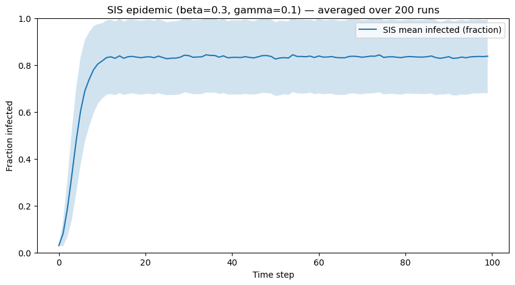

```python
beta = 0.3
gamma = 0.1
initial_frac = 0.05
t_max = 100
n_runs = 200

def initialize_states(G, initial_frac):
    states = {}
    for node in G.nodes():
        states[node] = 'S'
    k = max(1, int(initial_frac * G.number_of_nodes()))
    infected_nodes = random.sample(list(G.nodes()), k)
    for n in infected_nodes:
        states[n] = 'I'
    return states

def step_SIR(G, states, beta, gamma):
    new_states = states.copy()
    for node in G.nodes():
        if states[node] == 'S':
            for nbr in G.neighbors(node):
                if states[nbr] == 'I':
                    if random.random() < beta:
                        new_states[node] = 'I'
                        break
    for node in G.nodes():
        if states[node] == 'I':
            if random.random() < gamma:
                new_states[node] = 'R'
    return new_states

def step_SIS(G, states, beta, gamma):
    new_states = states.copy()
    for node in G.nodes():
        if states[node] == 'S':
            for nbr in G.neighbors(node):
                if states[nbr] == 'I' and random.random() < beta:
                    new_states[node] = 'I'
                    break
        elif states[node] == 'I':
            if random.random() < gamma:
                new_states[node] = 'S'
    return new_states

def run_simulation(G, model='SIR', beta=0.3, gamma=0.1, initial_frac=0.05, t_max=100):
    states = initialize_states(G, initial_frac)
    S, I, R = [], [], []
    for t in range(t_max):
        counts = {'S':0,'I':0,'R':0}
        for node in G.nodes():
            counts[states[node]] += 1
        S.append(counts['S'])
        I.append(counts['I'])
        R.append(counts['R'])
        if model == 'SIR':
            states = step_SIR(G, states, beta, gamma)
        elif model == 'SIS':
            states = step_SIS(G, states, beta, gamma)
        else:
            raise ValueError("model must be 'SIR' or 'SIS'")
    return np.array(S), np.array(I), np.array(R)

def multiple_runs(G, model, runs, **kwargs):
    results_I = []
    for r in range(runs):
        S,I,R = run_simulation(G, model=model, **kwargs)
        results_I.append(I)
    results_I = np.array(results_I)  # shape (runs, t_max)
    mean_I = results_I.mean(axis=0)
    std_I = results_I.std(axis=0)
    return mean_I, std_I

print("Simulating... (this may take a moment)")
mean_I_sir, std_I_sir = multiple_runs(G, 'SIR', n_runs, beta=beta, gamma=gamma, initial_frac=initial_frac, t_max=t_max)
mean_I_sis, std_I_sis = multiple_runs(G, 'SIS', n_runs, beta=beta, gamma=gamma, initial_frac=initial_frac, t_max=t_max)

N = G.number_of_nodes()
t = np.arange(t_max)

plt.figure(figsize=(10,5))
plt.plot(t, mean_I_sir / N, label='SIR mean infected (fraction)')
plt.fill_between(t, (mean_I_sir - std_I_sir)/N, (mean_I_sir + std_I_sir)/N, alpha=0.2)
plt.xlabel('Time step')
plt.ylabel('Fraction infected')
plt.title(f'SIR epidemic (beta={beta}, gamma={gamma}) — averaged over {n_runs} runs')
plt.ylim(0,1)
plt.legend()
plt.show()

plt.figure(figsize=(10,5))
plt.plot(t, mean_I_sis / N, label='SIS mean infected (fraction)')
plt.fill_between(t, (mean_I_sis - std_I_sis)/N, (mean_I_sis + std_I_sis)/N, alpha=0.2)
plt.xlabel('Time step')
plt.ylabel('Fraction infected')
plt.title(f'SIS epidemic (beta={beta}, gamma={gamma}) — averaged over {n_runs} runs')
plt.ylim(0,1)
plt.legend()
plt.show()
```